# Summary Statistical Inference Course

Desiré De Waele

24 maart 2016

# Conditional probability

## Definition

$P(A ~|~ B) = \frac{P(A \cap B)}{P(B)}$

## Bayes’ rule

$P(B ~|~ A) = \frac{P(A ~|~ B) P(B)}{P(A ~|~ B) P(B) + P(A ~|~ B^c)P(B^c)}.$

## Diagnostic tests

- Sensitivity - probability that the test is positive given that the subject actually has the disease, $P(+ ~|~ D)$
- Specificity - probability that the test is negative given that the subject does not have the disease, $P(- ~|~ D^c)$
- Positive predicted value - probability that the subject has the disease given that the test is positive, $P(D ~|~ +)$
- Negative predicted value - probability that the subject does not have the disease given that the test is negative, $P(D^c ~|~ -)$
- Prevalence - marginal probability of disease, $P(D)$

# Expected values

## Population Mean

$E[X] = \sum_x xp(x)$

## Sample Mean

$\bar X = \sum_{i=1}^n x_i p(x_i)$

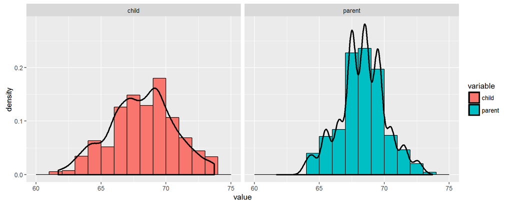

```r
library(UsingR); data(galton); library(ggplot2); library(reshape2)
longGalton <- melt(galton, measure.vars = c("child", "parent"))
g <- ggplot(longGalton, aes(x = value))
g <- g + geom_histogram(aes(y = ..density.., fill = variable), binwidth=1, color = "black")
g <- g + geom_density(size = 1)
g <- g + facet_grid(. ~ variable)
g
```

# Variance

## Population Variance

$\sigma^2 = Var(X) = E[(X - \mu)^2] = E[X^2] - E[X]^2$

## Sample Variance

$S^2 = \frac{\sum_{i=1} (X_i - \bar X)^2}{n-1}$

## Standard Error of the Mean

$S / \sqrt{n}$

# Common distributions

$P(X = x) = \left( \begin{array}{c} n \ x \end{array} \right) p^x(1 - p)^{n-x}$ Suppose a friend has 8 children, 7 of which are girls and none are twins. If each gender has an independent 50% probability for each birth, what’s the probability of getting 7 or more girls out of 8 births? $\left( \begin{array}{c} 8 \ 7 \end{array} \right) .5^{7}(1-.5)^{1} + \left( \begin{array}{c} 8 \ 8 \end{array} \right) .5^{8}(1-.5)^{0} \approx 0.04$

## Normal distribution

- Approximately 68%, 95% and 99% of the normal density lies within 1, 2 and 3 standard deviations from the mean, respectively.
- 1.28, 1.645, 1.96 and 2.33 are the 90th, 95th, 97:5th and 99th percentiles of the standard normal distribution, respectively.

# Central Limit Theorem

The sample means of any distribution approximate a normal distribution. The mean is the population mean $\mu$, the variance is the standard error, the population variance $\sigma$ divided by $\sqrt{n}$. $\frac{\bar X_n - \mu}{\sigma / \sqrt{n}}= \frac{\sqrt n (\bar X_n - \mu)}{\sigma} = \frac{\mbox{Estimate} - \mbox{Mean of estimate}}{\mbox{Std. Err. of estimate}}$

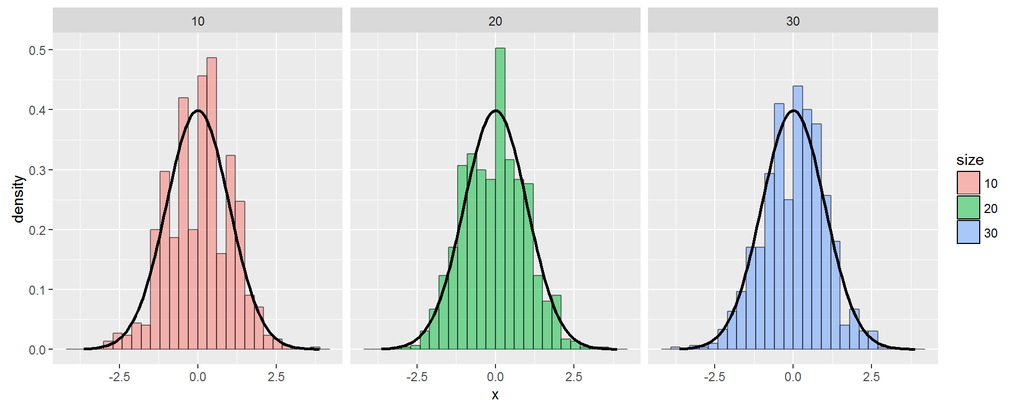

```r
nosim <- 1000
cfunc <- function(x, n) sqrt(n) * (mean(x) - 3.5) / 1.71
dat <- data.frame(x = c(apply(matrix(sample(1 : 6, nosim * 10, replace = TRUE), nosim), 1, cfunc, 10),
                        apply(matrix(sample(1 : 6, nosim * 20, replace = TRUE), nosim), 1, cfunc, 20),
                        apply(matrix(sample(1 : 6, nosim * 30, replace = TRUE), nosim), 1, cfunc, 30)),
                  size = factor(rep(c(10, 20, 30), rep(nosim, 3))))

g <- ggplot(dat, aes(x = x, fill = size))
g <- g + geom_histogram(alpha = .50, binwidth=.3, colour = "black", aes(y = ..density..))
g <- g + stat_function(fun = dnorm, size = 1)
g <- g + facet_grid(. ~ size); g
```